# Using Models 1

Aliza Fassler

11/7/2021

I worked alone on this assignment.

```r
require(here)
catrate = read.csv(here("data", "catrate.csv"))
```

# **Q1 (1 pt.): Create a histogram of the salamander reproduction catastrophic rates.**

**Make sure you include an appropriate title and label for the x-axis.**

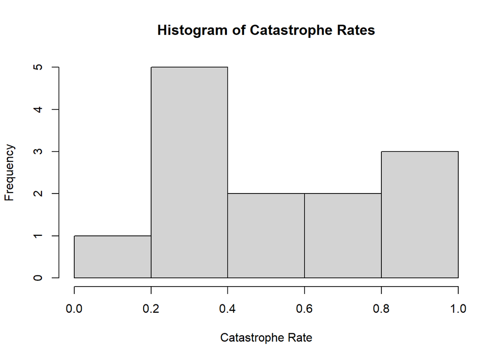

```r
hist(catrate$cat.rate, main = "Histogram of Catastrophe Rates", xlab = "Catastrophe Rate")
```

# **Q2 (1 pt.): Conduct a Shapiro-Wilk test of normality of the salamander catastrophic rates. Report the p-value and show the R-code you used to conduct the test.**

```r
shapiro.test(catrate$cat.rate)
```

```
##
##  Shapiro-Wilk normality test
##
## data:  catrate$cat.rate
## W = 0.86202, p-value = 0.04097
```

p-value = 0.041

# **Q3 (1 pt.): What is the null hypothesis for the Shapiro test?**

The null hypothesis of the shapiro test is that the sample is drawn from a normally distributed population. In this specific case the null hypothesis is that the population of all possible marbled salamander catastrophe rates is normally distributed.

# **Q4 (1 pt.): Based on the Shapiro test results, is there strong evidence that the sample came from a non-normally-distributed population?**

Based on the shapiro test there is strong evidence that the sample came from a non-normally distributed population. A p-value of 0.041 indicates that there is a 4% false positive rate, that is to say that 96% of the time a sample with this variance structure would not be drawn from a normally distributed population. Our false positive rate is 4%, meaning that we have a very low chance of drawing a really odd sample from a normally distributed population that would look like the cat.rate data sample.

# **Q5 (1 pt.): Show the code you used to conduct the t-test.**

```r
t.test(catrate$cat.rate, mu = 2/7)
```

```
##
##  One Sample t-test
##
## data:  catrate$cat.rate
## t = 2.9595, df = 12, p-value = 0.01193
## alternative hypothesis: true mean is not equal to 0.2857143
## 95 percent confidence interval:
##  0.3526250 0.7261295
## sample estimates:
## mean of x
## 0.5393773
```

# **Q6 (1 pt.): State the null hypothesis of the test, in plain nontechnical English.**

The null hypothesis of this t.test is that the true population mean based on our sample data is equal to 2/7. Even though our observed catrate has a mean of 0.54 our null hypothesis is asking how likely is it that we would get a mean of 0.54 if the overall larger population of all possible salamander catastrophe rates has a mean of 2/7.

# **Q7 (1 pt.): Is this a one- or two-tailed test?**

This is a two-tailed test.

# **Q8 (2 pts.): What is the p-value from your t-test? Interpret the p-value as a false-positive rate using nontechnical English that a non-scientist would understand.**

The p-value from this t-test is 0.012. This means that ~99% of the time we would expect to see a sample mean of 0.54 if the population mean is not equal to 2/7. Our false positive rate is 1.2%, meaning that 1.2% of the time just by chance alone we might get a really weird sample from a population (a population of all possible marbled salamander catastrophe rates) that has a sample mean of 0.54 when the population mean is actually 2/7.